# Resistance and Tolerance

Clay Morrow

2025-07-09

## 1 Introduction

This document will track the analysis of the resistance to and tolerance of *Borrelia* (B.b.) in *Peromyscus* mice at NEON.

## 2 Data

First, we’ll load in the data from Vania and rename a few of the columns.

```r
# read the excel file containing immune + infection data
df <- readxl::read_excel(
  "infection-modeling/data/Immune and burden Table.xlsx", na = c("", "NA")
) %>% tibble()

# clean it and keep only needed columns
df <- df %>%
  select(
    # Linking ID variables
    plotID, tagID = tagID.x, collectDate, trapCoordinate,
    # updated taxon information
    DFA_Taxon = `DFA ID`, Gel_Taxon = `Gel ID`,
    # geneetic info
    genetics_ID = `RNA/DNA ID #`,
    Bb_burden = `Bb burden (OspA/10kRpp30)`, Bb_status = `Bb Pos/Neg`,
    `IL-10`:`GATA-3`,
    # individual traits
  ) %>% distinct() %>%
  relocate(`TGF-B`, .before = `GATA-3`)
```

Then we’ll merge these data with the small mammal trapping data from NEON.

```r
# read mammal trap data
mammals <- readRDS("infection-modeling/data/full-data.rds")
# count the trapping observations
n_mammals = nrow(mammals)
```

```r
# join the tables together
mammals <- left_join(
  mammals, df, by = c("plotID", "trapCoordinate", "collectDate", "tagID")
)
# check that the rows haven't changed
stopifnot(nrow(mammals) == n_mammals)

mammals <- mammals %>%
  mutate(Bb_infected = (Bb_status == "Positive"))
```

## 3 Genetic correlations

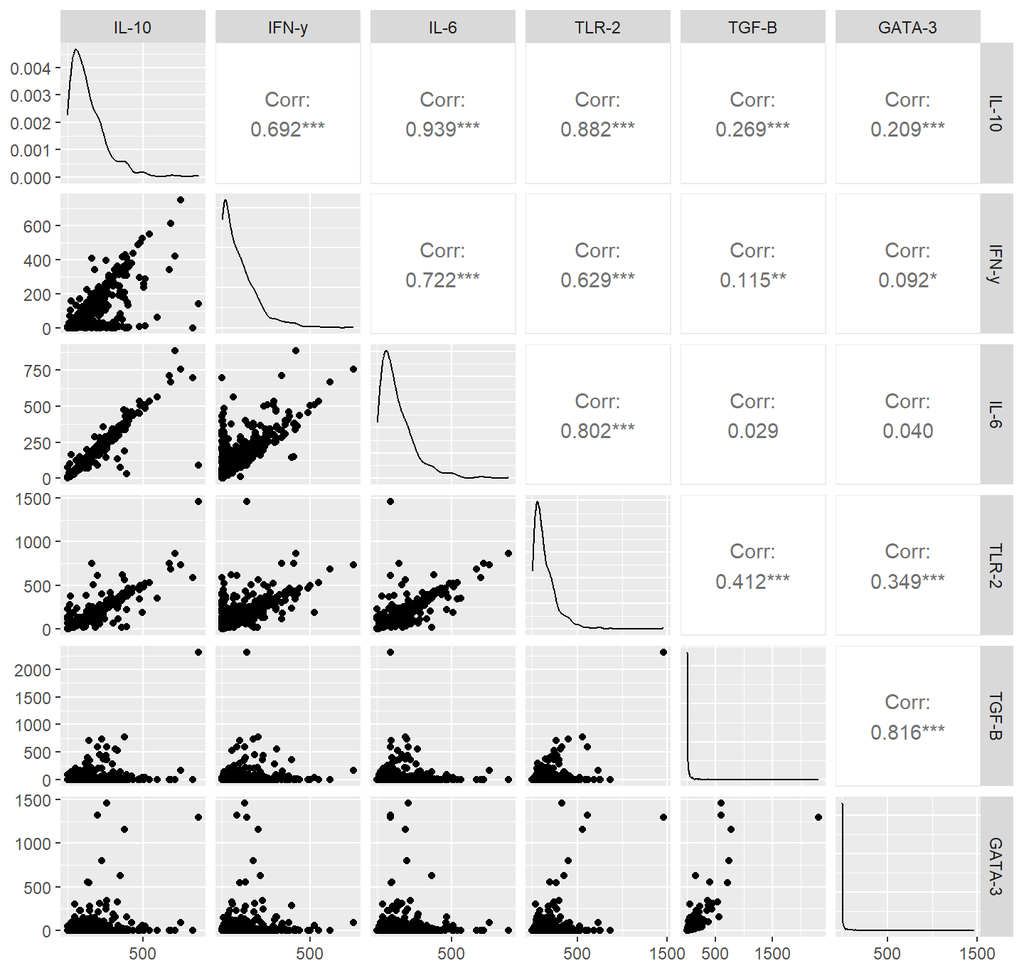

Figure 1: Genetic correlations

### 3.1 PCA

The resistance and tolerance genetic traits also broadly group together in a PCA (expression variables log(x + 1) transformed prior to ordination):

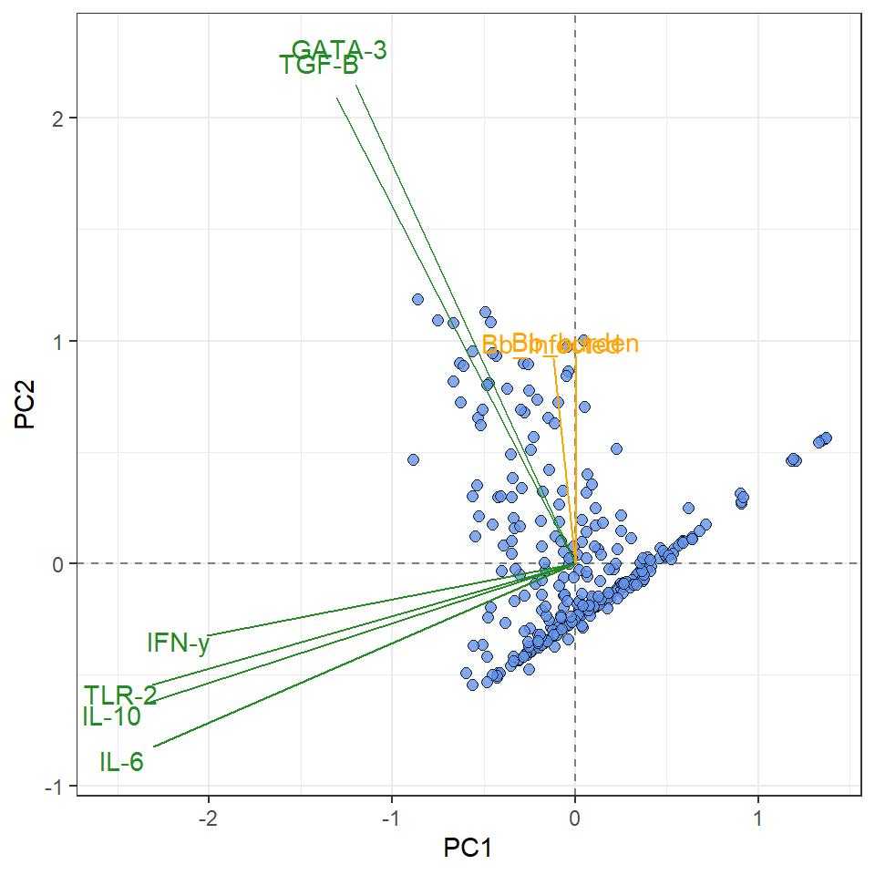

Figure 2: Genetic PCA

It appears that Bb infection status is significantly associated with our expression PCs, while burden is only marginally significant (based on permutation tests):

```
##
## ***VECTORS
##
##                   PC1       PC2     r2    Pr(>r)
## Bb_infected -0.129167  0.991620 0.0489 0.0004998 ***
## Bb_burden    0.007576  0.999970 0.0145 0.0824588 .
## ---
## Signif. codes:  0 '***' 0.001 '**' 0.01 '*' 0.05 '.' 0.1 ' ' 1
## Permutation: free
## Number of permutations: 2000
```

And below are visualizations of the relationships between the individual PC axes and our Bb variables:

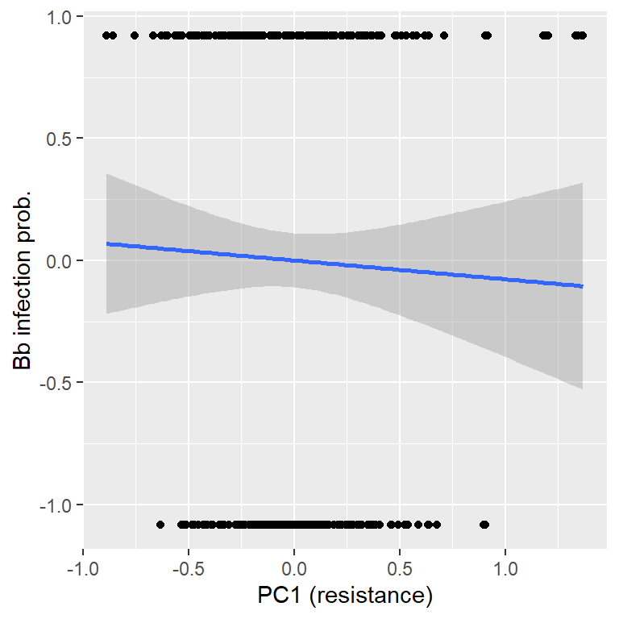

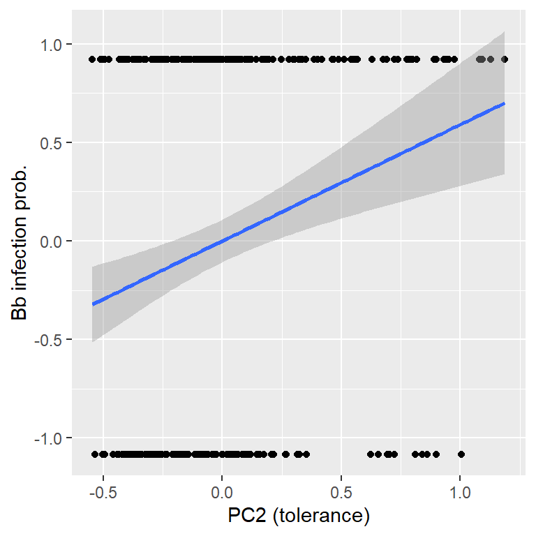

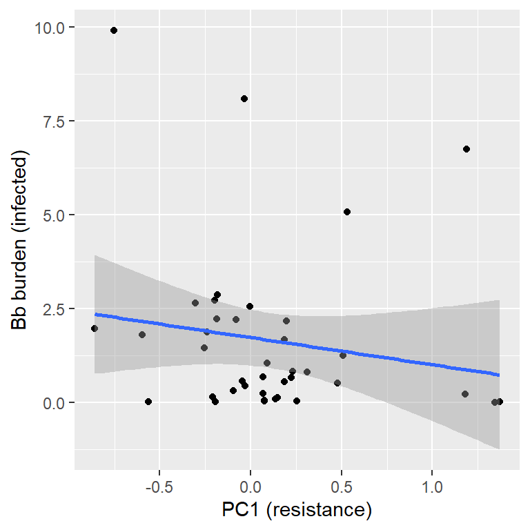

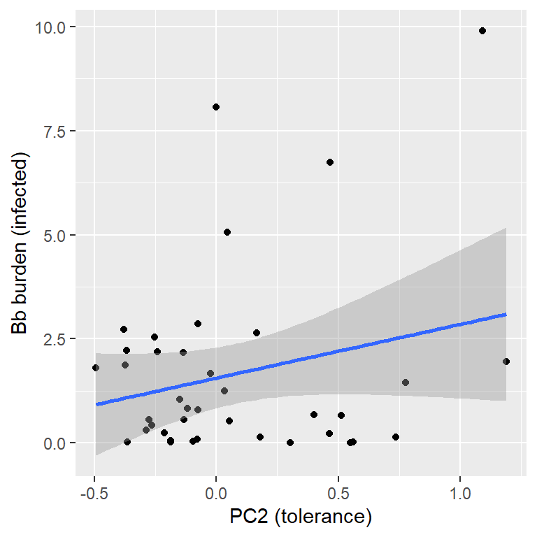

A multivariate regression of the Bb variables reveals that the significance that we saw before is almost entirely due to the tolerance axis (PC2):

```
## Response Bb_infected :
##
## Call:
## lm(formula = Bb_infected ~ PC1 + PC2, data = .)
##
## Residuals:
##     Min      1Q  Median      3Q     Max
## -1.6733 -0.9726  0.3977  0.9742  1.1984
##
## Coefficients:
##               Estimate Std. Error t value Pr(>|t|)
## (Intercept) -2.218e-16  5.504e-02   0.000    1.000
## PC1         -7.692e-02  1.484e-01  -0.518    0.605
## PC2          5.905e-01  1.484e-01   3.980 8.57e-05 ***
## ---
## Signif. codes:  0 '***' 0.001 '**' 0.01 '*' 0.05 '.' 0.1 ' ' 1
##
## Residual standard error: 0.9783 on 313 degrees of freedom
## Multiple R-squared:  0.04895,    Adjusted R-squared:  0.04287
## F-statistic: 8.054 on 2 and 313 DF,  p-value: 0.0003882
##
##
## Response Bb_burden :
##
## Call:
## lm(formula = Bb_burden ~ PC1 + PC2, data = .)
##
## Residuals:
##     Min      1Q  Median      3Q     Max
## -0.6012 -0.2693 -0.1973 -0.1290  9.5398
##
## Coefficients:
##              Estimate Std. Error t value Pr(>|t|)
## (Intercept) 6.571e-17  5.602e-02   0.000   1.0000
## PC1         2.453e-03  1.510e-01   0.016   0.9871
## PC2         3.237e-01  1.510e-01   2.143   0.0329 *
## ---
## Signif. codes:  0 '***' 0.001 '**' 0.01 '*' 0.05 '.' 0.1 ' ' 1
##
## Residual standard error: 0.9959 on 313 degrees of freedom
## Multiple R-squared:  0.01446,    Adjusted R-squared:  0.008166
## F-statistic: 2.297 on 2 and 313 DF,  p-value: 0.1023
```

Note though, that the R-squared values are quite low.

### 3.2 Transformations

Because of the distribution of these genetic trait values, transformations are likely necessary such as the square-root transformation shown in the next figure, but we will also group these values by quartile and decile later on.

Square-root or log transforming the resistance variables does help their distributions a bit, though they are still not fully Guassian. Unfortunately, a lot of data is lost with log-transformations (due to zeros), especially among tolerance traits.

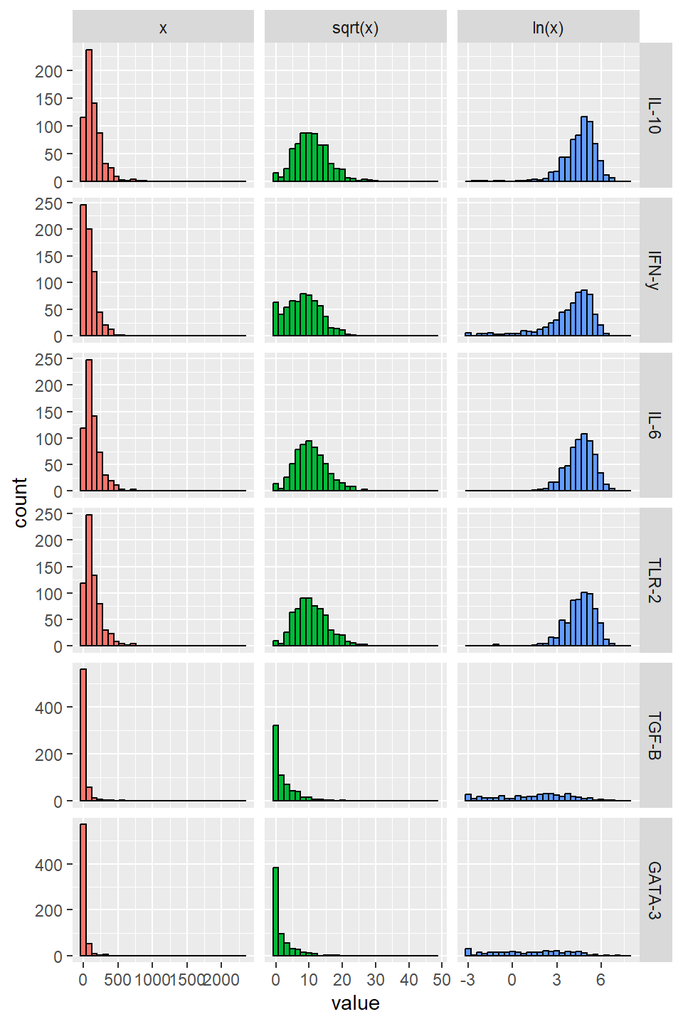

Figure 3: Genetic traits histogram, before and after transformations

## 4 B.b. variable distributions

*Borrelia* burden data are heavily zero-inflated, unsurprisingly, and there are about equal numbers of B.b. positive and negative individuals.

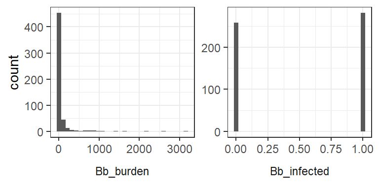

Figure 4: B.b. variable histograms

Similar to the genetic traits, square-root transforming the burden data helps with the skew. Log-transforming does an even better job, but can’t handle the zeros. This latter option is likely to be used with an infection hurdle model.

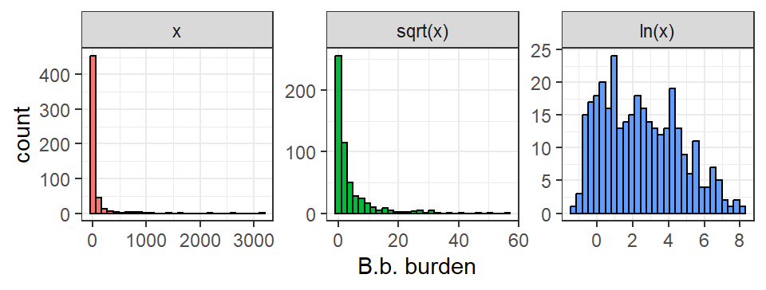

Figure 5: distribution of B.b. burden before and after transformations

## 5 Infection status modeling

Because of the zero-inflation of the B.b. burden data, we will look at the factors affecting B.b. in two parts (i.e., hurdle model). The first part is to look at the factors affecting the probability of being infected (binary) and the second part is to model the burden given that an individual is infected (i.e., zeros removed).

The figures below assess the relationships between the genetic traits and B.b. infection status.

The first shows that, there aren’t any strong patterns between the untransformed genetic traits and B.b. status. It also reveals that there are some rather extreme outliers among the genetic traits:

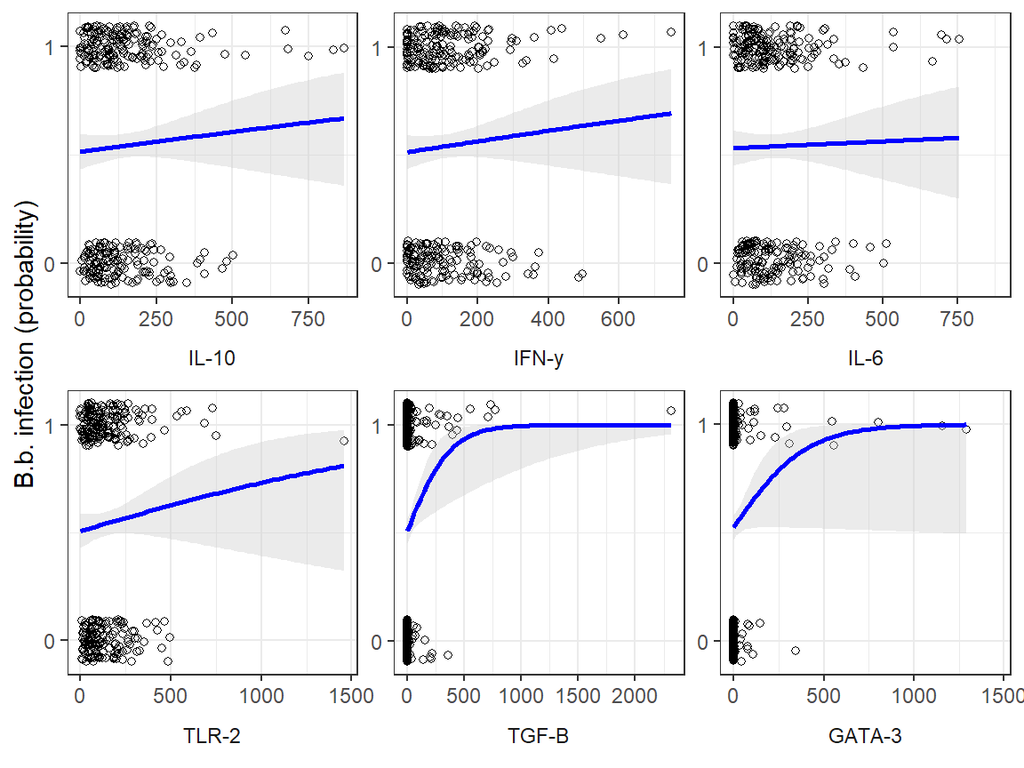

Figure 6: Relationships between genetic traits and B.b. infection

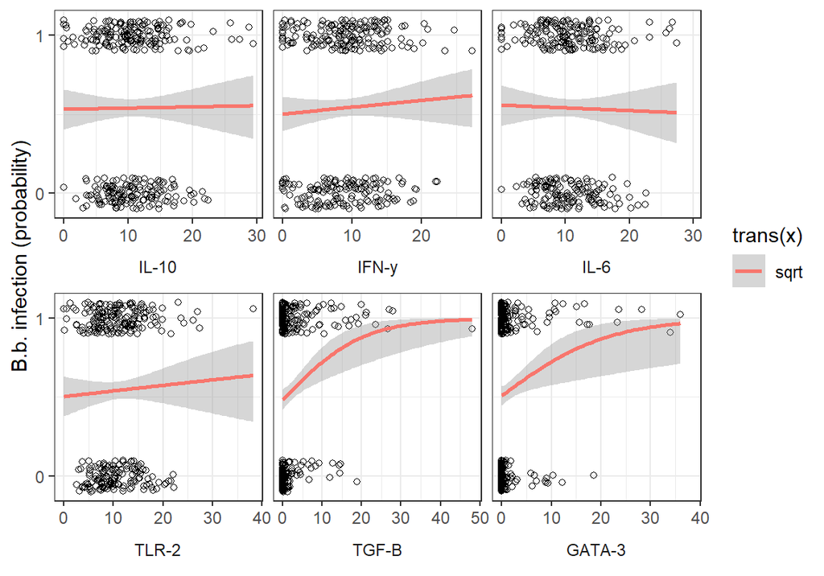

Figure 7: Relationships between sqrt-transformed genetic traits and B.b. infection

If we break the genetic traits into quartiles, we observe a slightly stronger patterns. Again, the strongest and clearest relationships are with the tolerance traits. Note that the blue points are mean proportion of infected individuals ± 95% confidence intervals for each quartile:

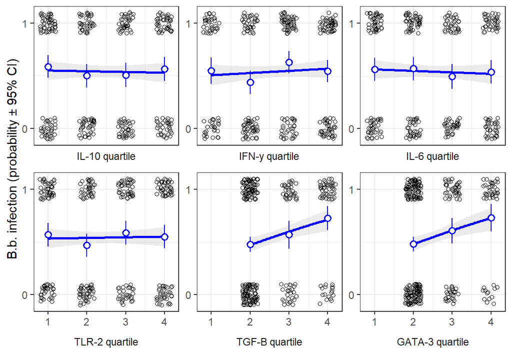

Figure 8: Relationships between genetic traits quartiles and B.b. infection

And the same patterns exist when we look at deciles:

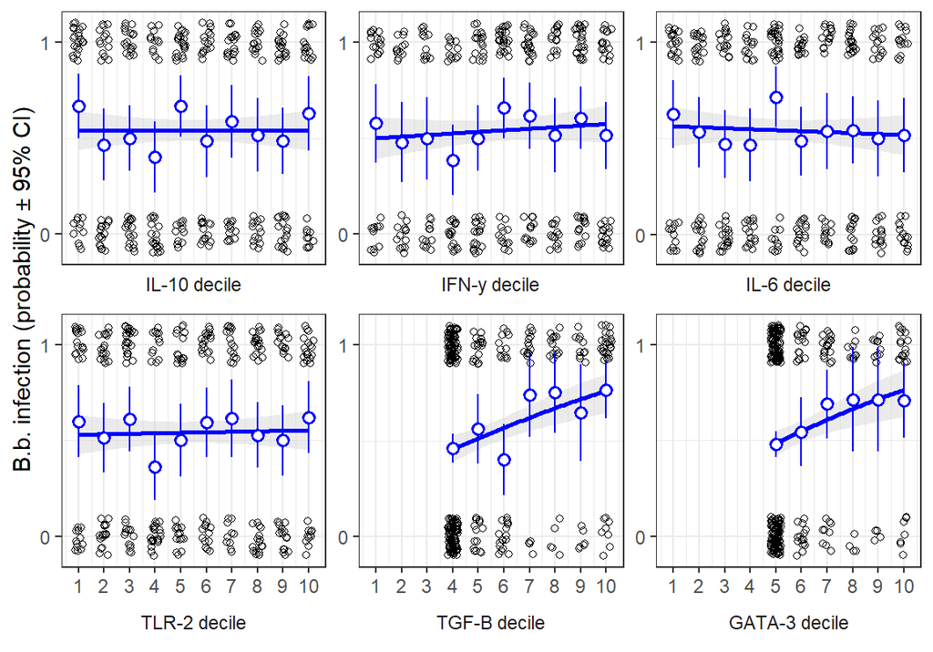

Figure 9: Relationships between genetic traits deciles and B.b. infection

### 5.1 Statistical models

Unfortunately, a generalized linear mixed effects (logistic regression) model using raw responses reveals that shows no significant effects (and very small effect sizes):

Table 1: Infection logistic GLMM model, with raw genetic traits.

|  | Coef | SE | z | P |
| --- | --- | --- | --- | --- |
| (Intercept) | -0.022 | 0.708 | -0.031 | 0.975 |
| `IL-10` | -0.002 | 0.005 | -0.514 | 0.607 |
| `IFN-y` | -0.005 | 0.003 | -1.858 | 0.063 |
| `IL-6` | 0.005 | 0.005 | 1.007 | 0.314 |
| `TGF-B` | 0.002 | 0.004 | 0.366 | 0.714 |
| `GATA-3` | 0.004 | 0.006 | 0.663 | 0.507 |

square-root transforming the predictor variables does not improve the significance:

Table 2: Infection logistic GLMM model, with sqrt-transformed genetic traits.

|  | Coef | SE | z | P |
| --- | --- | --- | --- | --- |
| (Intercept) | 0.193 | 0.738 | 0.262 | 0.794 |
| `sqrt_IL-10` | -0.085 | 0.115 | -0.737 | 0.461 |
| `sqrt_IFN-y` | -0.097 | 0.052 | -1.879 | 0.060 |
| `sqrt_IL-6` | 0.123 | 0.122 | 1.005 | 0.315 |
| `sqrt_TGF-B` | 0.067 | 0.100 | 0.674 | 0.500 |
| `sqrt_GATA-3` | 0.022 | 0.117 | 0.187 | 0.852 |

Nor does standardizing the predictor variables:

Table 3: Infection logistic GLMM model, with z-scaled genetic traits.

|  | Coef | SE | z | P |
| --- | --- | --- | --- | --- |
| (Intercept) | 0.015 | 0.695 | 0.022 | 0.983 |
| `scaled_IL-10` | -0.286 | 0.555 | -0.516 | 0.606 |
| `scaled_IFN-y` | -0.493 | 0.265 | -1.864 | 0.062 |
| `scaled_IL-6` | 0.599 | 0.593 | 1.009 | 0.313 |
| `scaled_TGF-B` | 0.189 | 0.520 | 0.362 | 0.717 |
| `scaled_GATA-3` | 0.445 | 0.677 | 0.658 | 0.510 |

However, if we exclude the top 5% of all the genetic traits, then the two tolerance variables (TGF-B and GATA-3) are significantly associated with B.b. infection. Probability of infection *incraeses* with increasing TGF-B expression and *decreases* with GATA-3, after accounting for the effects of the other variables:

Table 4: Infection logistic GLMM model, with extreme genetic traits removed.

|  | Coef | SE | z | P |
| --- | --- | --- | --- | --- |
| (Intercept) | 0.145 | 0.598 | 0.243 | 0.808 |
| `IL-10` | -0.008 | 0.008 | -0.997 | 0.319 |
| `IFN-y` | -0.005 | 0.004 | -1.155 | 0.248 |
| `IL-6` | 0.009 | 0.008 | 1.108 | 0.268 |
| `TGF-B` | 0.060 | 0.029 | 2.056 | 0.040 |
| `GATA-3` | -0.111 | 0.051 | -2.183 | 0.029 |

The same is likely true for using quartiles/deciles, but I haven’t fit those models yet.

## 7 Weather

One important component of the SEMs will be a measure of climate. PCA allows us to take a series of climatic variables and simplify them to a single index variable that encompasses them. Here we include both the mean and coefficient of variation for temperature, precipitation, and relative humidity. We will also perform the PCA at three different scales: the site scale (average climate across 8 years), the annual scale (average climate within a single year at a site), and the month scale (average climate within a single month at a site).

Here is a quick look at the site-scale weather PCA, where PC1 explains 65% of the total variation and PC2 explains an additional 27%:

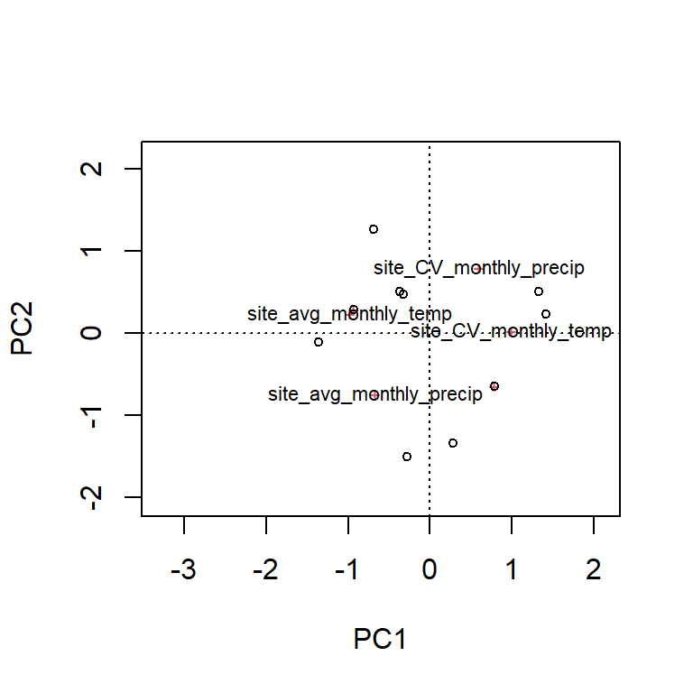

```
## Importance of components:
##                          PC1    PC2     PC3    PC4      PC5      PC6
## Eigenvalue            3.9152 1.6258 0.24984 0.1440 0.041644 0.023486
## Proportion Explained  0.6525 0.2710 0.04164 0.0240 0.006941 0.003914
## Cumulative Proportion 0.6525 0.9235 0.96514 0.9891 0.996086 1.000000
```

Here is a breakdown of PC1 across the sites and the loadings of the different climate variables:

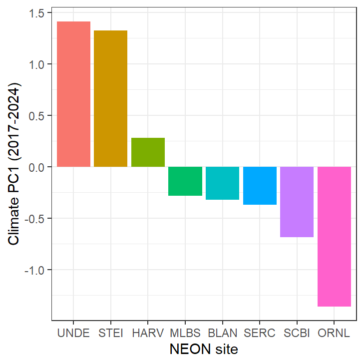

| variable | PC1 |
| --- | --- |
| site_CV_monthly_temp | 0.993 |
| site_avg_monthly_RH | 0.785 |
| site_CV_monthly_precip | 0.602 |
| site_avg_monthly_precip | -0.669 |
| site_CV_monthly_RH | -0.933 |
| site_avg_monthly_temp | -0.973 |

Because this site-scale PCA seems to place relative humidity and precipitation on opposite sides of the PC1 axis, so I’d like to visualize the relationship of these two variables with temperature. From this, we can see that at sites with the highest lowest average temperatures, average humidity and precipitation are less linked than at the sites with more middling average temperatures:

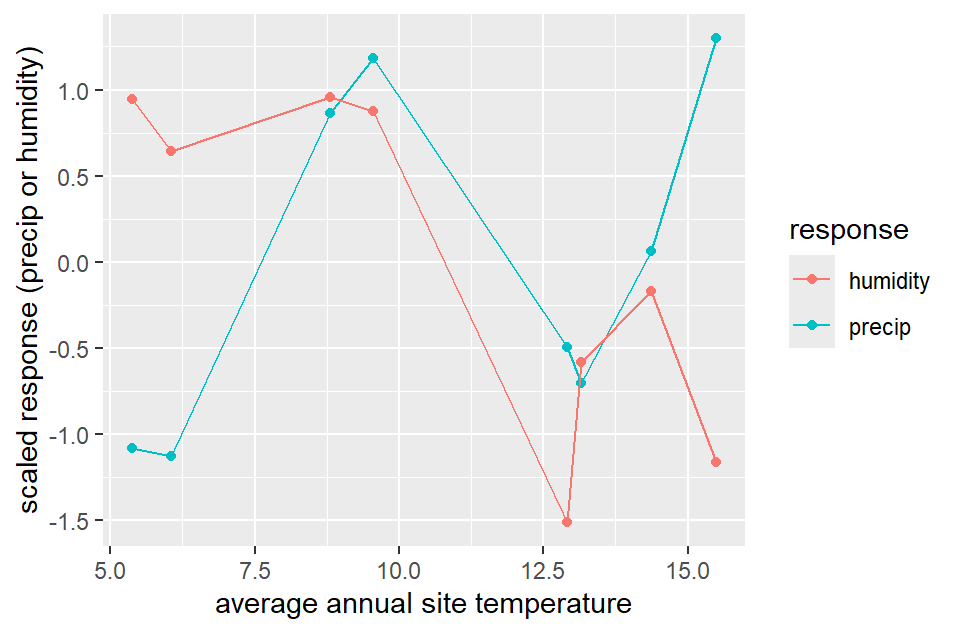

Here is the annual-scale PCA, where PC1 explains 48% of the variation and PC2 explains an additional 22%.

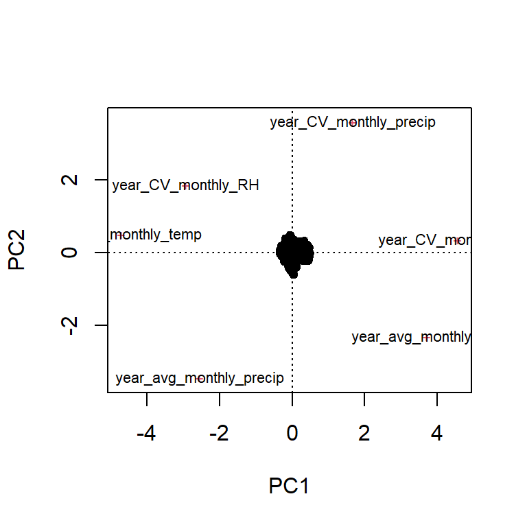

```
## Importance of components:
##                          PC1    PC2    PC3    PC4     PC5     PC6
## Eigenvalue            2.8604 1.3081 0.7811 0.6102 0.36203 0.07814
## Proportion Explained  0.4767 0.2180 0.1302 0.1017 0.06034 0.01302
## Cumulative Proportion 0.4767 0.6948 0.8249 0.9266 0.98698 1.00000
```

The monthly climate PCA (not visualized) further reduces the explanatory power of the PC axes with PC1 explaining only 30% of the climate variation and PC2 explaining an additional 24%:

```
## Importance of components:
##                          PC1    PC2    PC3    PC4    PC5     PC6
## Eigenvalue            1.8199 1.4637 1.0022 0.9744 0.5334 0.20644
## Proportion Explained  0.3033 0.2439 0.1670 0.1624 0.0889 0.03441
## Cumulative Proportion 0.3033 0.5473 0.7143 0.8767 0.9656 1.00000
```

## 8 Resistance/Tolerance PCA

Next, we will try to reduce the resistance and tolerance genetic expression variables into PCA axes, as we did with weather. In this case, we will fit separate PCAs for resistance (4 variables) and tolerance (2 variables) and will use the first PC axis as the index.

The resistance PC1 explains 77% of the variation among the (log-transformed) resistance variables, and is well correlated with those variables (only one shown):

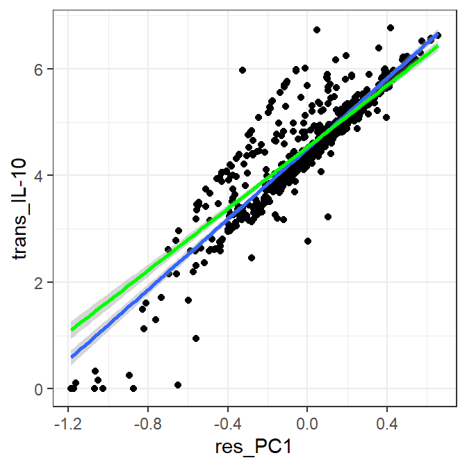

```
##                         PC1   PC2   PC3   PC4
## Eigenvalue            4.996 1.248 0.190 0.047
## Proportion Explained  0.771 0.193 0.029 0.007
## Cumulative Proportion 0.771 0.964 0.993 1.000
```

The tolerance PC1 explains 97% of the variation in the two (log-transformed) tolerance variables:

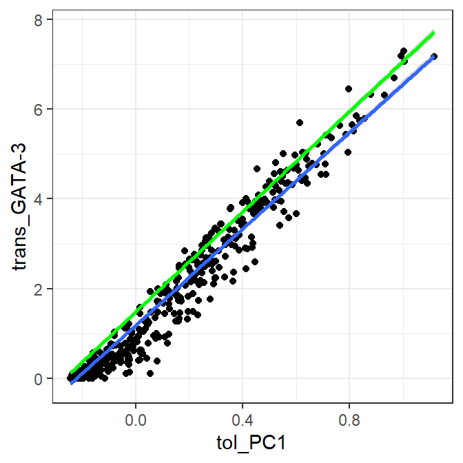

```
##                         PC1   PC2
## Eigenvalue            5.728 0.193
## Proportion Explained  0.967 0.033
## Cumulative Proportion 0.967 1.000
```

## 9 SEMs:

In this section, we will look at SEMs that involve resistance and tolerance. Specifically, we are interested in resistance and tolerance as *latent* variables for tick attachment and *Borrelia* infection.

### 9.1 Tick attachment

First, we’ll build a model whose ultimate response variable is tick attachment. These models will include resistance and tolerance as predictors of tick attachment as well as factors that might predict resistance and tolerance. We will also try to incorporate mouse behavior (e.g., capture time) into these models.

#### 9.1.1 model 1

The first model tries to replicate the model that Alli built, but adding an additional year of data. This model is not identical to the one Alli fit: rather than fitting the sub-models (lmer and glmer) to the *individual* scale (by summarizing variables across recaptures), we use fit to the individual *observation* scale (including individual ID as a random effect). This prevents the need to summarize and maximizes the available information (and power).

The results are somewhat interesting:

```
##
## Structural Equation Model of fsem1
##
## Call:
##   cap_prop_night ~ sex_male + weight
##   ticks_attatched ~ siteClimatePC1 + cap_prop_night + sex_male * sex_mature
##   res_PC1 ~ siteClimatePC1 * year + sex_mature + weight + sex_male
##   tol_PC1 ~ weight + year + sex_male * cap_prop_night + ticks_attatched * sex_mature
##
##     AIC
##  3373.749
##
## ---
## Tests of directed separation:
##
##                          Independ.Claim Test.Type        DF Crit.Value P.Value
##          ticks_attatched ~ weight + ...      coef 2251.0000    -1.6031  0.1089
##   cap_prop_night ~ siteClimatePC1 + ...      coef    5.9655     0.9522  0.3671
##          tol_PC1 ~ siteClimatePC1 + ...      coef    5.8088     0.3878  0.5571
##       cap_prop_night ~ sex_mature + ...      coef 2604.6789     0.7693  0.3805
##             cap_prop_night ~ year + ...      coef 1239.0196     3.9640  0.0467
##            ticks_attatched ~ year + ...      coef 2304.0000    -1.6118  0.1070
##          res_PC1 ~ cap_prop_night + ...      coef  494.6890     1.4236  0.2334
##         res_PC1 ~ ticks_attatched + ...      coef  195.0386     1.6811  0.1963
##                 tol_PC1 ~ res_PC1 + ...      coef  391.7463    20.1552  0.0000
##
##
##
##
##
##     *
##
##
##
##   ***
##
## --
## Global goodness-of-fit:
##
## Chi-Squared = 152.663 with P-value = 0 and on 11 degrees of freedom
```

[output cut: 45 more lines]

```
##       3.7699  0.0536       0.1482
##       0.9366  0.3338       0.0623
##       0.5275  0.4681       0.1285
##       0.0082  0.9279       0.0087
##
##   Signif. codes:  0 '***' 0.001 '**' 0.01 '*' 0.05
##
## ---
## Individual R-squared:
##
##          Response      method Marginal Conditional
##    cap_prop_night        none     0.02        0.15
##   ticks_attatched theoretical     0.17        0.43
##           res_PC1        none     0.08        0.86
##           tol_PC1        none     0.11        0.81
```

Below is a visualization of the sex-maturity interaction:

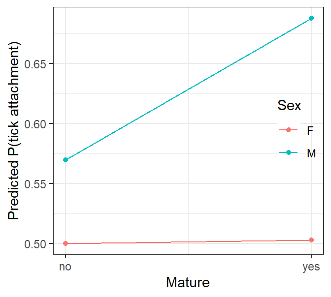

Next, we update the model to include the suggested missing components. Non-significant paths have not yet been removed.

```
##
## Structural Equation Model of fsem1.corr
##
## Call:
##   cap_prop_night ~ sex_male + weight + year
##   ticks_attatched ~ siteClimatePC1 + cap_prop_night + sex_male * sex_mature
##   res_PC1 ~ siteClimatePC1 * year + sex_mature + weight + sex_male
##   tol_PC1 ~ weight + year + sex_male + cap_prop_night + ticks_attatched + sex_mature + res_PC1 + sex_male:cap_prop_night + ticks_attatched:sex_mature
##
##     AIC
##  3365.344
##
## ---
## Tests of directed separation:
##
##                          Independ.Claim Test.Type        DF Crit.Value P.Value
##          ticks_attatched ~ weight + ...      coef 2251.0000    -1.6031  0.1089
##            ticks_attatched ~ year + ...      coef 2304.0000    -1.6118  0.1070
##   cap_prop_night ~ siteClimatePC1 + ...      coef    5.9598     0.9157  0.3758
##          tol_PC1 ~ siteClimatePC1 + ...      coef    5.9548     0.0216  0.8880
##       cap_prop_night ~ sex_mature + ...      coef 2637.0750     0.3475  0.5556
##          res_PC1 ~ cap_prop_night + ...      coef  494.6896     1.4236  0.2334
##         res_PC1 ~ ticks_attatched + ...      coef  195.0386     1.6811  0.1963
##
## --
## Global goodness-of-fit:
##
## Chi-Squared = 132.433 with P-value = 0 and on 8 degrees of freedom
## Fisher's C = 18.441 with P-value = 0.187 and on 14 degrees of freedom
##
## ---
## Coefficients:
##
##          Response                  Predictor Estimate Std.Error        DF
##    cap_prop_night                   sex_male   0.0363    0.0105  980.8610
##    cap_prop_night                     weight   0.0063    0.0011 1869.4823
##    cap_prop_night                       year  -0.0129    0.0065 1239.0194
##   ticks_attatched             siteClimatePC1  -1.0012    0.3348 2304.0000
##   ticks_attatched             cap_prop_night  -0.4329    0.2126 2304.0000
##   ticks_attatched                   sex_male   0.2832    0.2042 2304.0000
```

[output cut: 37 more lines]

```
##       1.6806  0.1956       0.0816
##      20.0601  0.0000       0.2384 ***
##       0.1992  0.6556       0.0769
##       0.0085  0.9267      -0.0087
##
##   Signif. codes:  0 '***' 0.001 '**' 0.01 '*' 0.05
##
## ---
## Individual R-squared:
##
##          Response      method Marginal Conditional
##    cap_prop_night        none     0.02        0.16
##   ticks_attatched theoretical     0.17        0.43
##           res_PC1        none     0.08        0.86
##           tol_PC1        none     0.14        0.85
```

Here’s a visualization of the model (significant paths only):

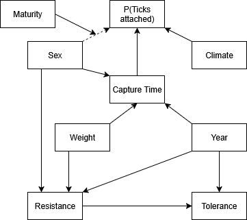

There are a few problems with this model, from my perspective:

- There are some missing links that seem obvious (i.e., the effect of climate on behavior).
- Year is treated as a numeric variable, which expects a constant trend through time. This assumption is not reasonable. Better approaches would be to either
1. include year as a random effect (note the lack of an interaction with year) or 2) conduct a group comparison, whereby the model is parameter differently for each year and testing which paths differ among years.
- The resistance and tolerance variables have a directed relationship. It is more appropriate to specify that these variables are adirectionally correlated. I tried fitting the model with this specification multiple times and it would not successfully fit.
- There are no significant links between ticks and resistance or tolerance, rather it is a model of the common factors that affect ticks, resistance, and tolerance. This is not completely uninteresting, but it does seem like there should be a direct link.

#### 9.1.2 model 2

[**UNDER CONSTRUCTION**]

```
##
## Structural Equation Model of res_tol_sem
##
## Call:
##   cap_prop_night ~ siteClimatePC1 + sex_male + weight
##   ticks_attatched ~ siteClimatePC1 + cap_prop_night + sex_male * sex_mature
##   res_PC1 ~ siteClimatePC1 + sex_mature + weight + sex_male
##   tol_PC1 ~ res_PC1 + weight + sex_male * cap_prop_night + ticks_attatched * sex_mature
##
##     AIC
##  812.565
##
## ---
## Tests of directed separation:
##
##                      Independ.Claim Test.Type       DF Crit.Value P.Value
##      tol_PC1 ~ siteClimatePC1 + ...      coef   6.5003     0.0081  0.9312
##      ticks_attatched ~ weight + ...      coef 342.0000    -0.2914  0.7707
##   cap_prop_night ~ sex_mature + ...      coef 313.7839     1.4353  0.2318
##      res_PC1 ~ cap_prop_night + ...      coef 330.1381     0.0053  0.9421
##     res_PC1 ~ ticks_attatched + ...      coef 163.7735     0.4789  0.4899
##
## --
## Global goodness-of-fit:
##
## Chi-Squared = NA with P-value = NA and on 6 degrees of freedom
## Fisher's C = 5.134 with P-value = 0.882 and on 10 degrees of freedom
##
## ---
## Coefficients:
##
##          Response                  Predictor Estimate Std.Error       DF
##    cap_prop_night             siteClimatePC1  -0.0440    0.0264   8.1900
##    cap_prop_night                   sex_male   0.0423    0.0277 271.3484
##    cap_prop_night                     weight   0.0061    0.0030 302.2910
##   ticks_attatched             siteClimatePC1  -0.8826    0.3945 342.0000
##   ticks_attatched             cap_prop_night  -0.8429    0.4634 342.0000
##   ticks_attatched                   sex_male   0.5210    0.4336 342.0000
##   ticks_attatched                 sex_mature   0.0703    0.4289 342.0000
##   ticks_attatched        sex_male:sex_mature   0.0722    0.5497 342.0000
```

[output cut: 29 more lines]

```
##       2.5599  0.1107       0.1253
##       3.1966  0.0747       0.1228
##       0.4840  0.4871       0.0693
##       0.0036  0.9521      -0.0051
##
##   Signif. codes:  0 '***' 0.001 '**' 0.01 '*' 0.05
##
## ---
## Individual R-squared:
##
##          Response      method Marginal Conditional
##    cap_prop_night        none     0.03        0.87
##   ticks_attatched theoretical     0.11        0.28
##           res_PC1        none     0.10        0.93
##           tol_PC1        none     0.05        0.65
```

| Response | Predictor | Estimate | Std.Error | DF | Crit.Value | P.Value | Std.Estimate |  |
| --- | --- | --- | --- | --- | --- | --- | --- | --- |
| cap_prop_night | siteClimatePC1 | -0.0440 | 0.0264 | 8.1900 | 2.5720 | 0.1466 | -0.1230 |  |
| cap_prop_night | sex_male | 0.0423 | 0.0277 | 271.3484 | 2.1412 | 0.1445 | 0.0797 |  |
| cap_prop_night | weight | 0.0061 | 0.0030 | 302.2910 | 3.8565 | 0.0505 | 0.1078 |  |
| ticks_attatched | siteClimatePC1 | -0.8826 | 0.3945 | 342.0000 | -2.2374 | 0.0253 | -0.3205 | * |
| ticks_attatched | cap_prop_night | -0.8429 | 0.4634 | 342.0000 | -1.8188 | 0.0689 | -0.1094 |  |
| ticks_attatched | sex_male | 0.5210 | 0.4336 | 342.0000 | 1.2015 | 0.2295 | 0.1274 |  |
| ticks_attatched | sex_mature | 0.0703 | 0.4289 | 342.0000 | 0.1640 | 0.8697 | 0.0170 |  |
| ticks_attatched | sex_male:sex_mature | 0.0722 | 0.5497 | 342.0000 | 0.1313 | 0.8955 | 0.0156 |  |
| res_PC1 | siteClimatePC1 | -0.0865 | 0.0459 | 6.2812 | 3.5267 | 0.1073 | -0.2147 |  |
| res_PC1 | sex_mature | -0.0251 | 0.0325 | 304.8591 | 0.5555 | 0.4567 | -0.0413 |  |
| res_PC1 | weight | -0.0109 | 0.0033 | 319.5091 | 10.4247 | 0.0014 | -0.1721 | ** |
| res_PC1 | sex_male | -0.0857 | 0.0292 | 231.5254 | 7.7690 | 0.0058 | -0.1432 | ** |
| tol_PC1 | res_PC1 | 0.1984 | 0.0560 | 302.7135 | 12.0625 | 0.0006 | 0.1838 | *** |
| tol_PC1 | weight | -0.0002 | 0.0035 | 326.8091 | 0.0019 | 0.9653 | -0.0023 |  |
| tol_PC1 | sex_male | -0.0186 | 0.0559 | 324.6305 | 0.1089 | 0.7416 | -0.0287 |  |
| tol_PC1 | cap_prop_night | -0.0511 | 0.0826 | 325.8398 | 0.3795 | 0.5383 | -0.0420 |  |
| tol_PC1 | ticks_attatched | 0.0811 | 0.0487 | 281.7075 | 2.5599 | 0.1107 | 0.1253 |  |
| tol_PC1 | sex_mature | 0.0804 | 0.0446 | 327.7695 | 3.1966 | 0.0747 | 0.1228 |  |
| tol_PC1 | sex_male:cap_prop_night | 0.0791 | 0.1134 | 325.1935 | 0.4840 | 0.4871 | 0.0693 |  |
| tol_PC1 | ticks_attatched:sex_mature | -0.0038 | 0.0615 | 323.7548 | 0.0036 | 0.9521 | -0.0051 |  |

```
##
## Structural Equation Model of alt_psem
##
## Call:
##   cap_prop_night ~ res_PC1 + tol_PC1 + siteClimatePC1 + sex_male + sex_mature + weight
##   ticks_attatched ~ res_PC1 + tol_PC1 + siteClimatePC1 + sex_mature + sex_male
##   res_PC1 ~ siteClimatePC1 + sex_mature + weight + sex_male
##   tol_PC1 ~ weight + sex_mature + sex_male
##   res_PC1 ~~ tol_PC1
##
##     AIC
##  813.893
##
## ---
## Tests of directed separation:
##
##                           Independ.Claim Test.Type       DF Crit.Value P.Value
##           tol_PC1 ~ siteClimatePC1 + ...      coef   6.3875     0.4811  0.5124
##           ticks_attatched ~ weight + ...      coef 342.0000    -0.4946  0.6209
##   ticks_attatched ~ cap_prop_night + ...      coef 342.0000    -1.6211  0.1050
##
## --
## Global goodness-of-fit:
##
## Chi-Squared = NA with P-value = NA and on 3 degrees of freedom
## Fisher's C = 6.798 with P-value = 0.34 and on 6 degrees of freedom
##
## ---
## Coefficients:
##
##          Response      Predictor Estimate Std.Error       DF Crit.Value P.Value
##    cap_prop_night        res_PC1   0.0019    0.0532 316.1646     0.0012  0.9723
##    cap_prop_night        tol_PC1  -0.0228    0.0481 147.8033     0.1884  0.6649
##    cap_prop_night siteClimatePC1  -0.0418    0.0272   8.0995     2.1959  0.1762
##    cap_prop_night       sex_male   0.0512    0.0291 292.8686     2.8620  0.0918
##    cap_prop_night     sex_mature   0.0406    0.0319 314.1238     1.4978  0.2219
##    cap_prop_night         weight   0.0045    0.0033 326.5263     1.8108  0.1794
##   ticks_attatched        res_PC1  -0.0916    0.4447 342.0000    -0.2059  0.8368
##   ticks_attatched        tol_PC1   1.3746    0.4314 342.0000     3.1861  0.0014
##   ticks_attatched siteClimatePC1  -0.8744     0.458 342.0000    -1.9094  0.0562
```

[output cut: 26 more lines]

```
##        -0.0354
##         0.1217  *
##         0.0092
##         0.1473 **
##
##   Signif. codes:  0 '***' 0.001 '**' 0.01 '*' 0.05
##
## ---
## Individual R-squared:
##
##          Response      method Marginal Conditional
##    cap_prop_night        none     0.03        0.86
##   ticks_attatched theoretical     0.12        0.33
##           res_PC1        none     0.10        0.93
##           tol_PC1        none     0.01        0.83
```

| Response | Predictor | Estimate | Std.Error | DF | Crit.Value | P.Value | Std.Estimate |  |
| --- | --- | --- | --- | --- | --- | --- | --- | --- |
| cap_prop_night | res_PC1 | 0.00 | 0.0532 | 316.16 | 0.00 | 0.97 | 0.00 |  |
| cap_prop_night | tol_PC1 | -0.02 | 0.0481 | 147.80 | 0.19 | 0.66 | -0.03 |  |
| cap_prop_night | siteClimatePC1 | -0.04 | 0.0272 | 8.10 | 2.20 | 0.18 | -0.12 |  |
| cap_prop_night | sex_male | 0.05 | 0.0291 | 292.87 | 2.86 | 0.09 | 0.10 |  |
| cap_prop_night | sex_mature | 0.04 | 0.0319 | 314.12 | 1.50 | 0.22 | 0.08 |  |
| cap_prop_night | weight | 0.00 | 0.0033 | 326.53 | 1.81 | 0.18 | 0.08 |  |
| ticks_attatched | res_PC1 | -0.09 | 0.4447 | 342.00 | -0.21 | 0.84 | -0.01 |  |
| ticks_attatched | tol_PC1 | 1.37 | 0.4314 | 342.00 | 3.19 | 0.00 | 0.21 | ** |
| ticks_attatched | siteClimatePC1 | -0.87 | 0.458 | 342.00 | -1.91 | 0.06 | -0.31 |  |
| ticks_attatched | sex_mature | -0.03 | 0.256 | 342.00 | -0.13 | 0.90 | -0.01 |  |
| ticks_attatched | sex_male | 0.51 | 0.2515 | 342.00 | 2.02 | 0.04 | 0.12 | * |
| res_PC1 | siteClimatePC1 | -0.09 | 0.0459 | 6.28 | 3.53 | 0.11 | -0.21 |  |
| res_PC1 | sex_mature | -0.03 | 0.0325 | 304.86 | 0.56 | 0.46 | -0.04 |  |
| res_PC1 | weight | -0.01 | 0.0033 | 319.51 | 10.42 | 0.00 | -0.17 | ** |
| res_PC1 | sex_male | -0.09 | 0.0292 | 231.53 | 7.77 | 0.01 | -0.14 | ** |
| tol_PC1 | weight | 0.00 | 0.0035 | 331.37 | 0.46 | 0.50 | -0.04 |  |
| tol_PC1 | sex_mature | 0.08 | 0.0347 | 332.11 | 5.12 | 0.02 | 0.12 | * |
| tol_PC1 | sex_male | 0.01 | 0.0314 | 315.30 | 0.03 | 0.85 | 0.01 |  |
| ~~res_PC1 | ~~tol_PC1 | 0.15 | - | 342.00 | 2.74 | 0.00 | 0.15 | ** |

```
##                           Independ.Claim Test.Type       DF Crit.Value P.Value
## 1         tol_PC1 ~ siteClimatePC1 + ...      coef   6.3875     0.4811  0.5124
## 2         ticks_attatched ~ weight + ...      coef 342.0000    -0.4946  0.6209
## 3 ticks_attatched ~ cap_prop_night + ...      coef 342.0000    -1.6211  0.1050
```

## 10 Question: What coverage do we have for recaptures within a capture event?

In total there are nearly 8000 individual *Peromyscus* individuals that were captured multiple times within a trapping event:

```
## [1] 22092
```

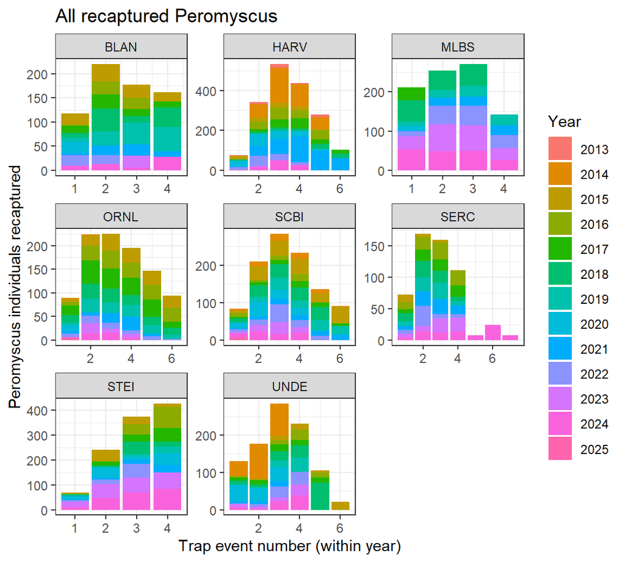

```
## [1] 7948
```

And of those individuals that were recaptured, over 1000 were also captured (and recaptured) in traps with ibuttons, allowing for estimation of capture time:

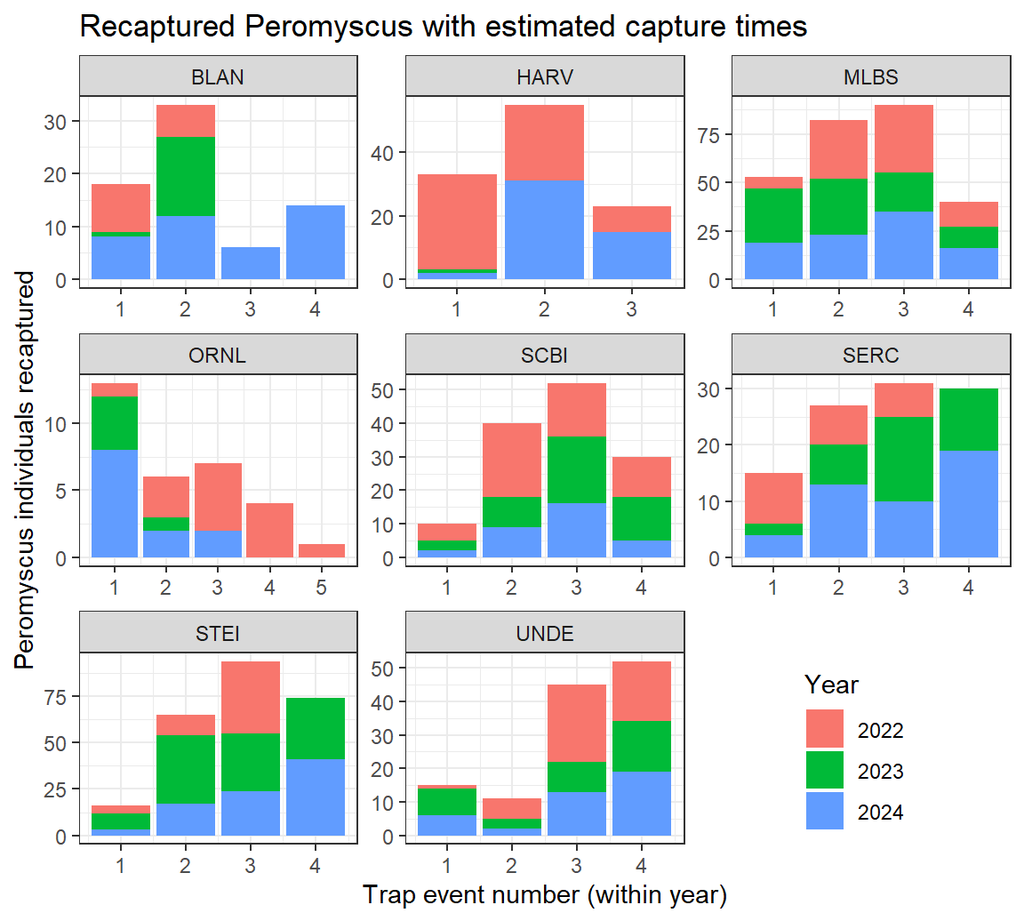

```
## [1] 1085
```

Below is a table containing the counts of *Peromyscus* recaptures, for which we have capture time estimates and multiple captures within a session, that breaks down whether or not an individual was recaptured with the same tick status (`changed_status`) as it had the first time it was captured (`initial_status`) for each tick life stage (`tickStage`). Note that `tickStage == "any"` refers to any tick regardless of life stage. Overall, relatively few individuals were recaptured with a different tick status than their first capture:

Table 5: Recaptured Peromyscus tick attachment status counts, by tick lifestage

| tickStage | initial_status | changed_status | n |
| --- | --- | --- | --- |
| larva | FALSE | FALSE | 458 |
| larva | FALSE | TRUE | 94 |
| larva | TRUE | FALSE | 256 |
| larva | TRUE | TRUE | 89 |
| nymph | FALSE | FALSE | 798 |
| nymph | FALSE | TRUE | 35 |
| nymph | TRUE | FALSE | 20 |
| nymph | TRUE | TRUE | 43 |
| adult | FALSE | FALSE | 894 |
| adult | FALSE | TRUE | 2 |
| any | FALSE | FALSE | 420 |
| any | FALSE | TRUE | 89 |
| any | TRUE | FALSE | 294 |
| any | TRUE | TRUE | 94 |

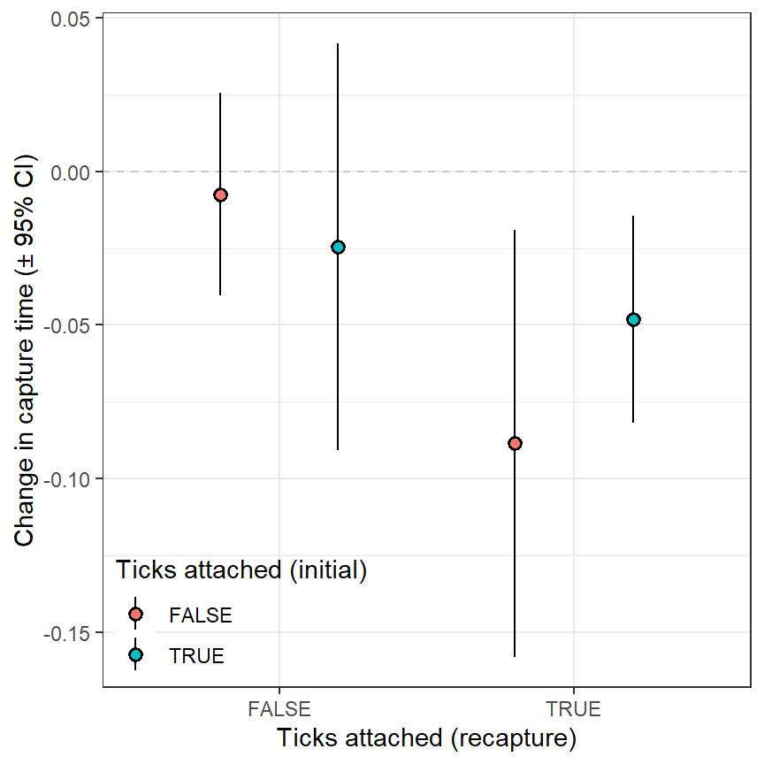

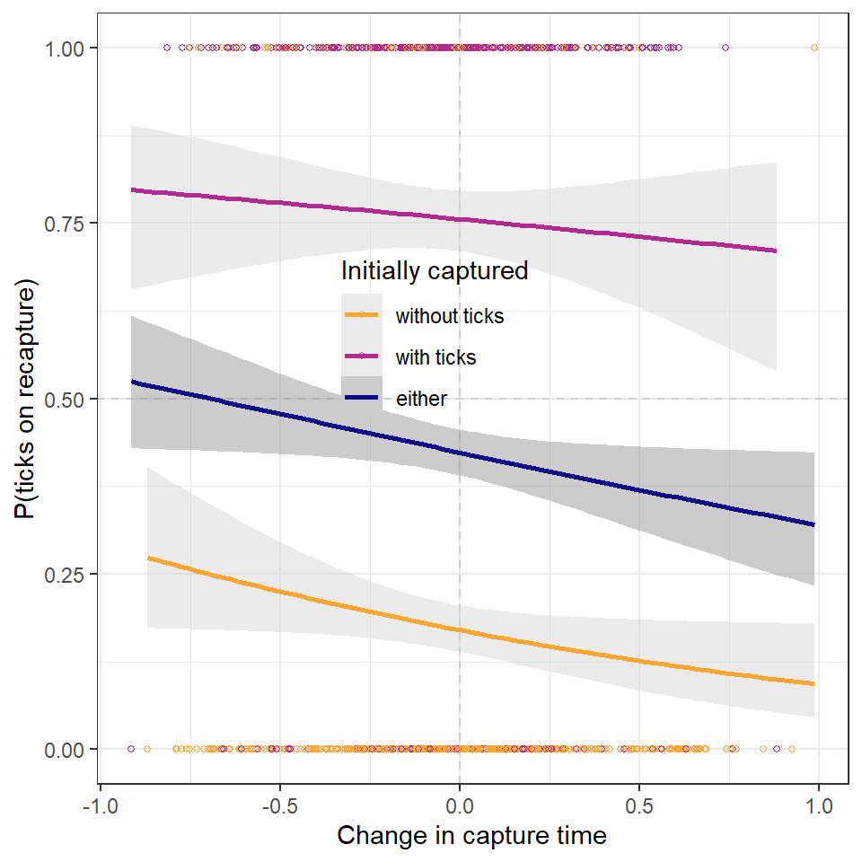

But that relationship is not significant (accounting for year, site, event, and individual as random effects). The only factor that strongly predicts whether a recapture has a tick is if the initial capture had a tick:

```r
library(lmerTest)

tick_time_fm <- glmer(
  attachStatus ~ cap_time_change * initial_status +
    (1|year) + (1|siteID) + (1|eventID) + (1|tagID),
  data = cap_tick_tab %>%
    filter(cap_num > 1, tickStage == "any") %>%
    mutate(
      attachStatus = as.numeric(attachStatus),
      initial_status = as.numeric(initial_status)
    )
)

# fixed effects
summary(tick_time_fm)$coefficients
```

```
##                                   Estimate Std. Error    t value
## (Intercept)                     0.23379777 0.05661918  4.1293034
## cap_time_change                -0.06106975 0.04911302 -1.2434533
## initial_status                  0.41365525 0.02981975 13.8718541
## cap_time_change:initial_status  0.07067464 0.07943176  0.8897528
```

```r
# random effects
VarCorr(tick_time_fm)
```

```
##  Groups   Name        Std.Dev.
##  tagID    (Intercept) 0.088320
##  eventID  (Intercept) 0.128300
##  siteID   (Intercept) 0.130992
##  year     (Intercept) 0.034498
##  Residual             0.351196
```

```r
# Type II ANOVA
car::Anova(tick_time_fm)
```

```
## Analysis of Deviance Table (Type II Wald chisquare tests)
##
## Response: attachStatus
##                                   Chisq Df Pr(>Chisq)
## cap_time_change                  0.7849  1     0.3756
## initial_status                 191.9700  1     <2e-16 ***
## cap_time_change:initial_status   0.7917  1     0.3736
## ---
## Signif. codes:  0 '***' 0.001 '**' 0.01 '*' 0.05 '.' 0.1 ' ' 1
```

And if we only look at those that started without ticks, the effect is still nonsignificant:

```r
upd <- update(
  tick_time_fm, . ~ . - initial_status - cap_time_change:initial_status,
  data = cap_tick_tab %>%
    filter(cap_num > 1, tickStage == "any", !initial_status) %>%
    mutate(
      attachStatus = as.numeric(attachStatus),
      initial_status = as.numeric(initial_status)
    )
  )

car::Anova(upd)
```

```
## Analysis of Deviance Table (Type II Wald chisquare tests)
##
## Response: attachStatus
##                  Chisq Df Pr(>Chisq)
## cap_time_change 1.9019  1     0.1679
```

**Is tick status (and the change thereof) associated with change in relative capture timing?**